# flows

Timothée Giraud, Laurent Beauguitte, Marianne Guérois

2022-03-03

# Introduction

The **`flows`** package contains functions that select flows, provide statistics on selections and propose map and graph visualisations.  
The first part of the vignette reminds several methods of flow selection, the second part presents the main functions of the package and the last one proposes an exemple of analysis based on commuters data in the French Grand Est region.

# Analysis of geographic flows: issues and methods

In the field of spatial analysis, working on flows implies to focus on the relationships between places rather than on their characteristics. Analysis and flow representation often assume a selection to ease the interpretation.

One of the first method developed was the so-called dominant flows (or nodal regions) proposed by Nystuen and Dacey in 1961[^1]. Working on telephone flows between cities in the Seattle area, they sought to highlight hierarchy between locations. According to this method, a place *i* is dominated by a place *j* if two conditions are met:

1. the most important flow from *i* is emitted towards *j*;
2. the sum of the flows received by *j* is greater than the sum of the flows received by *i*.

This method creates what is called in graph theory a tree (acyclic graph) or a forest (a set of unconnected trees) with three types of nodes: dominant, dominated and intermediate. If the method creates a clear functional hierarchy, its major drawback is to undervalue flows intensities.

Various methods have subsequently been proposed to better reflect this intensity, one of the most frequently used being the so-called major flows: it selects only the most important flows, absolute or relative, either locally or globally. Analysing commuters data between cities, one may choose to select:

- all flows greater than 100;
- the 50 first flows (global criterion);
- the 10 first flows emitted by each city (local criterion).

These criteria can also be expressed in relative form:

- flows that represent more than 10% of the active population of each city (local criterion);
- flows that take into account 80% of all commuters (global criterion).

These methods often highlight hierarchies between places but the loss of information created by the selection is rarely questioned. Hence, it seems useful to propose statistical indicators to assess loss of information and characteristics of the selected flows.

# The `flows` package

A typical data workflow may be:

1. data preparation
2. flow selection
3. statistics and graphics on the selection
4. graph or map (for dominant flows)

## Data Preparation

```r
library(flows)
# Import data
nav <- read.csv(system.file("csv/nav.csv", package = "flows"))
head(nav, 4)
```

```
##   i namei      wi   j    namej      wj  fij
## 1 1 Paris 5599722   1    Paris 5599722 1698
## 2 1 Paris 5599722  48   Troyes   75562    4
## 3 1 Paris 5599722 129     Sens   24625  287
## 4 1 Paris 5599722 529 Vouziers    2120    4
```

```r
# Prepare data
mat <- prepare_mat(x = nav, i = "i", j = "j", fij = "fij")
mat[1:4,1:4]
```

```
##       1      9     20     24
## 1  1698      0      0      0
## 9     0 298895    402    281
## 20    0    264 154743   3040
## 24    0    259   4500 129717
```

## Flow Selection

- `nfirst`: the `k` first flows from all origins;
- `xfirst`: all flows greater than a threshold `k`;
- `xsumfirst`: as many flows as necessary for each origin so that their sum is at least equal to `k`.

Figure 1: The three methods of the `select_flows()` function

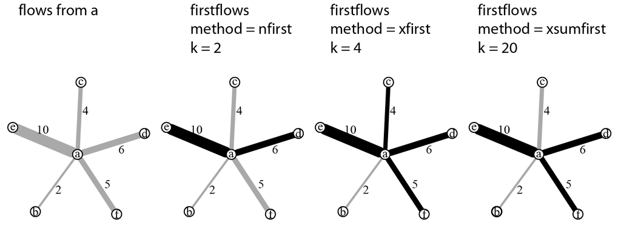

**Black links are the selected ones.**

Methods taking into account the total volume of flows are implemented when using `global = TRUE` parameter. They are identical to the ones described above: selection of the `k` first flows, selection of flows greater than `k` and selection of flows such as the sum is at least equal to `k`.

The `dominant` method selects flows based on a dominance test. This function may be used to select flows obeying the second criterion of Nystuen and Dacey method.

All these functions take as input a square matrix of flows and generate binary matrices of the same size. Selected flows are coded 1, others 0. It is therefore possible to combine criteria of selection through element-wise multiplication of matrices (Figure 2).

Figure 2: Flow selection and criteria combination

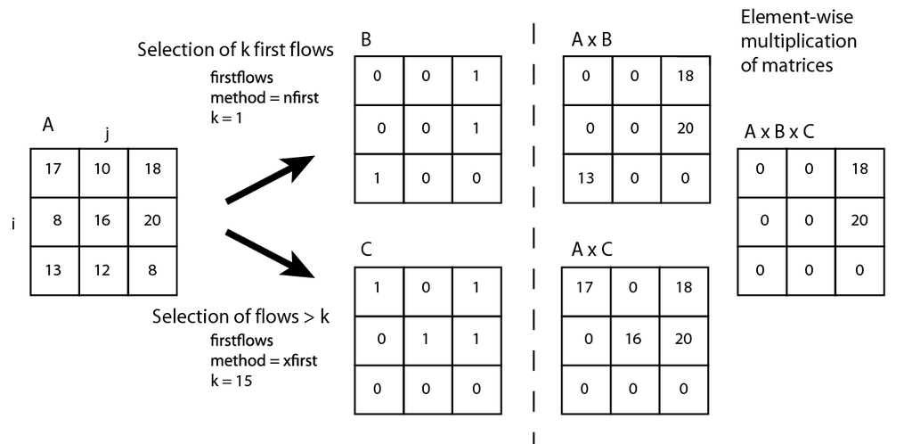

## Statistics and Graphics

The `stat_mat()` function provides various indicators and graphical outputs on a flow matrix to allow statistically sound selections. Measures provided are density (number of present flows divided by the number of possible flows); number, size and composition of connected components; sum, quartiles and average intensity of flows. In addition, four graphics can be plotted: degree distribution curve (by default, outdegree), weighted degree distribution curve, Lorenz curve and boxplot on flow intensities.

```r
# Import data
nav <- read.csv(system.file("csv/nav.csv", package = "flows"))
# Prepare data
mat <- prepare_mat(x = nav, i = "i", j = "j", fij = "fij")

# Get statistics about the matrix
stat_mat(mat = mat, output = "none", verbose = TRUE)
```

```
## matrix dimension: 159 X 159
## nb. links: 3350
## density: 0.1333493
## nb. of components (weak) 1
## nb. of components (weak, size > 1) 1
## sum of flows: 2306577
## min: 1
## Q1: 4
## median: 10
## Q3: 55
## max: 298895
## mean: 688.5304
## sd: 7765.106
```

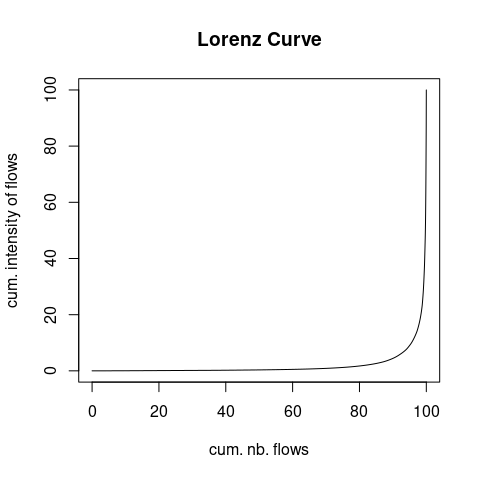

```r
# Plot Lorenz curve only
stat_mat(mat = mat, output = "lorenz", verbose = FALSE)
```

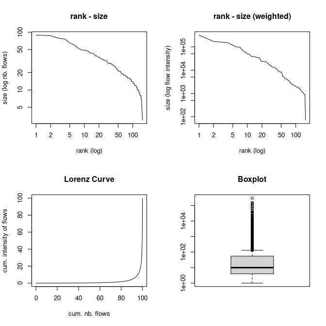

```r
# Graphics only
stat_mat(mat = mat, output = "all", verbose = FALSE)
```

```r
# Statistics only
mystats <- stat_mat(mat = mat, output = "none", verbose = FALSE)
str(mystats)
```

```
## List of 16
##  $ matdim      : int [1:2] 159 159
##  $ nblinks     : num 3350
##  $ density     : num 0.133
##  $ connectcomp : int 1
##  $ connectcompx: int 1
##  $ sizecomp    :'data.frame':    1 obs. of  3 variables:
##   ..$ idcomp  : int 1
##   ..$ sizecomp: num 159
##   ..$ wcomp   : num 2306577
##  $ compocomp   :'data.frame':    159 obs. of  2 variables:
##   ..$ id    : chr [1:159] "1" "9" "20" "24" ...
##   ..$ idcomp: num [1:159] 1 1 1 1 1 1 1 1 1 1 ...
##  $ degrees     :'data.frame':    159 obs. of  3 variables:
##   ..$ id     : chr [1:159] "1" "9" "20" "24" ...
##   ..$ degree : num [1:159] 7 89 78 76 87 61 65 55 44 49 ...
##   ..$ wdegree: num [1:159] 2021 318299 170691 148765 157821 ...
##  $ sumflows    : num 2306577
##  $ min         : num 1
##  $ Q1          : num 4
##  $ median      : num 10
##  $ Q3          : num 55
##  $ max         : num 298895
##  $ mean        : num 689
##  $ sd          : num 7765
```

```r
# Sum of flows
mystats$sumflows
```

```
## [1] 2306577
```

Visualisation helps analysis, `plot_nodal_flow()` function produces a graph where sizes and colors of vertices depend on their position in the graph (dominant, intermediate or dominated) and thicknesses of links depend on flow intensites.

The `map_nodal_flows()` function maps the selected flows according to the same principles.

Both functions only apply to a dominant flows selection[^2].

# Example: Commuters flows in the French Grand Est

As an illustration, we present a brief analysis of commuter flows between urban areas of the Grand Est region in France[^3].

We compare two different thresholds (500 and 1000) on the total volume of flows.

```r
# Import data
nav <- read.csv(system.file("csv/nav.csv", package = "flows"))
# Prepare data
mat <- prepare_mat(x = nav, i = "i", j = "j", fij = "fij")

# Remove the matrix diagonal
diag(mat) <- 0

# Selection of flows > 500
mat_sel_1 <- select_flows(mat = mat, method = "xfirst", k = 500)

# Selection of flows > 1000
mat_sel_2 <- select_flows(mat = mat, method = "xfirst", k = 1000)

# Compare initial matrix and selected matrices
compare_mat(mat1 = mat, mat2 = mat * mat_sel_1, digits = 0)
```

```
##                mat1   mat2 absdiff reldiff
## nblinks        3191    137    3054      96
## sumflows     313292 193203  120089      38
## connectcompx      1     10       9      NA
## min               1    502      NA      NA
## Q1                4    584      NA      NA
## median            8    880      NA      NA
## Q3               41   1702      NA      NA
## max            8654   8654      NA      NA
## mean             98   1410      NA      NA
## sd              400   1343      NA      NA
```

```r
compare_mat(mat1 = mat, mat2 = mat * mat_sel_2, digits = 0)
```

```
##                mat1   mat2 absdiff reldiff
## nblinks        3191     62    3129      98
## sumflows     313292 145368  167924      54
## connectcompx      1      7       6      NA
## min               1   1021      NA      NA
## Q1                4   1253      NA      NA
## median            8   1792      NA      NA
## Q3               41   2938      NA      NA
## max            8654   8654      NA      NA
## mean             98   2345      NA      NA
## sd              400   1543      NA      NA
```

If we select flows greater than 500 commuters, we loose 96% of all links but only 38% of the volume of flows. With a threshold of 1000 commuters, 98% of links are lost but only 54% of the volume of flows.

The following exemple selects flows that represent at least 20% of the sum of outgoing flows for each urban area.

```r
# Import data
nav <- read.csv(system.file("csv/nav.csv", package = "flows"))
# Prepare data
mat <- prepare_mat(x = nav, i = "i", j = "j", fij = "fij")

# Remove the matrix diagonal
diag(mat) <- 0

# Percentage of each outgoing flows
mat_p <- mat  / rowSums(mat) * 100

# Select flows that represent at least 20% of the sum of outgoing flows for
# each urban area.
mat_p_sel <- select_flows(mat = mat_p, method = "xfirst", k = 20)

# Compare initial and selected matrices
compare_mat(mat1 = mat, mat2 = mat * mat_p_sel)
```

```
##                mat1   mat2 absdiff reldiff
## nblinks        3191    240    2951      92
## sumflows     313292 167088  146204      47
## connectcompx      1      6       5      NA
## min               1      3      NA      NA
## Q1                4    156      NA      NA
## median            8    323      NA      NA
## Q3               41    584      NA      NA
## max            8654   8654      NA      NA
## mean             98    696      NA      NA
## sd              400   1148      NA      NA
```

This selection keeps only 8% of all links and 53% of the flows volume.

We decide run a dominant flow analysis on this dataset. `nodal_flows()` combines the two critiria in a single function and returns a flow matrix.

```r
nav <- read.csv(system.file("csv/nav.csv", package = "flows"))
mat <- prepare_mat(x = nav, i = "i", j = "j", fij = "fij")
res <- nodal_flows(mat)

compare_mat(mat1 = mat, mat2 = res)
```

```
##                 mat1   mat2 absdiff reldiff
## nblinks         3350    134    3216      96
## sumflows     2306577 100781 2205796      96
## connectcompx       1     25      24      NA
## min                1      4      NA      NA
## Q1                 4    188      NA      NA
## median            10    382      NA      NA
## Q3                55    588      NA      NA
## max           298895   8654      NA      NA
## mean             689    752      NA      NA
## sd              7765   1192      NA      NA
```

This analysis keeps 4% of all links and 4% ot the flows volume.

```r
library(sf)
```

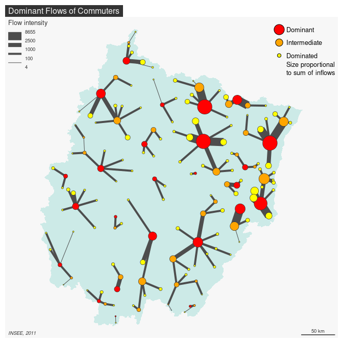

```r
library(mapsf)
nav <- read.csv(system.file("csv/nav.csv", package = "flows"))
mat <- prepare_mat(x = nav, i = "i", j = "j", fij = "fij")
UA <- st_read(system.file("gpkg/GE.gpkg", package = "flows"),
              layer = "urban_area", quiet = TRUE)
GE <- st_read(system.file("gpkg/GE.gpkg", package = "flows"),
              layer = "region", quiet = TRUE)
mf_map(GE, col = "#cceae7", border = NA)
out <- map_nodal_flows(mat = mat, x = UA,
                       col_node = c('red', 'orange', 'yellow'),
                       col_flow = "grey30",
                       breaks = c(4,100,1000,2500,8655),
                       lwd = c(1,4,8,16), add = TRUE)
mf_title("Dominant Flows of Commuters")
mf_credits("INSEE, 2011")
mf_scale()
```

```r
head(out$nodes[order(out$nodes$w, decreasing = TRUE), 2:3, drop = TRUE])
```

```
##                             name     w
## 3                          Nancy 18119
## 2  Strasbourg (partie francaise) 18057
## 4                           Metz 17927
## 7                       Mulhouse 14577
## 13                        Colmar  9666
## 15                       Belfort  8785
```

The top of the node hierarchy brings out clearly, in descending order, the domination of Nancy, Strasbourg, Metz and Mulhouse, each attracting more than 10 000 commuters.

One could easily repeat these selections, with higher or smaller thresholds, to identify the most robust connections and the intermittent ones.

# Conclusion

**`flows`** aims at enabling relevant flows selections, while leaving maximum flexibility to the user.